# Homework #8

Darien Lozon

April 11, 2019

1. Load data and place into an unmarkedFrameOccu object.

```r
setwd("C:/Users/Darien Lozon/Google Drive/SP19 Courses/WMAN633/")
y <- read.csv('Bobcat.csv')
bob_mat <- as.matrix(y)

site_covs <- read.csv('psi covariates.csv')
p <- read.csv('p covariates.csv')

det_covs <- list(people=p)
library(unmarked)
occu_dat <- unmarkedFrameOccu(y=bob_mat,
                          siteCovs=site_covs,
                          obsCovs=det_covs)
```

2. Assume the following candidate set of models:

| Detection model | Occupancy model |
| --- | --- |
| intercept-only | intercept-only |
| people | intercept-only |
| intercept-only | disturbance |
| people | disturbance |

Fit these models, and perform model selection with AIC. What is your top model? How do you know? Is there model selection uncertainty?

```r
fit1 <- occu(~1~1,occu_dat)
fit2 <- occu(~people~1,occu_dat)
fit3 <- occu(~1~Dist_5km,occu_dat)
fit4 <- occu(~people~Dist_5km,occu_dat)

cand.set <- list(
  M1 = fit1, M2 = fit2, M3 = fit3, M4 = fit4
)
library(AICcmodavg)
mods <- aictab(cand.set=cand.set,second.ord=F); mods
```

```
##
## Model selection based on AIC:
##
##    K     AIC Delta_AIC AICWt Cum.Wt       LL
## M3 3 4461.01      0.00  0.73   0.73 -2227.50
## M4 4 4462.98      1.97  0.27   1.00 -2227.49
## M1 2 4490.77     29.77  0.00   1.00 -2243.39
## M2 3 4492.73     31.72  0.00   1.00 -2243.36
```

3. Average both the effect of people on detection and disturbance on occupancy over all models. Report model-averaged slope coefficients and 95% confidence intervals.

```r
ppl <- modavgShrink(cand.set=cand.set,
                    parm='people',
                    second.ord=F,
                    parm.type='detect')
dst <- modavgShrink(cand.set=cand.set,
                    parm='Dist_5km',
                    second.ord=F,
                    parm.type='psi')

ppl; dst
```

```
##
## Multimodel inference on "p(people)" based on AIC
##
## AIC table used to obtain model-averaged estimate with shrinkage:
##
##    K     AIC Delta_AIC AICWt Estimate   SE
## M1 2 4490.77     29.77  0.00     0.00 0.00
## M2 3 4492.73     31.72  0.00    -0.08 0.38
## M3 3 4461.01      0.00  0.73     0.00 0.00
## M4 4 4462.98      1.97  0.27    -0.06 0.38
##
## Model-averaged estimate with shrinkage: -0.02
## Unconditional SE: 0.2
## 95% Unconditional confidence interval: -0.41, 0.37
```

```
##
## Multimodel inference on "psi(Dist_5km)" based on AIC
##
## AIC table used to obtain model-averaged estimate with shrinkage:
##
##    K     AIC Delta_AIC AICWt Estimate   SE
## M1 2 4490.77     29.77  0.00     0.00 0.00
## M2 3 4492.73     31.72  0.00     0.00 0.00
## M3 3 4461.01      0.00  0.73   -23.65 4.77
## M4 4 4462.98      1.97  0.27   -23.64 4.77
##
## Model-averaged estimate with shrinkage: -23.65
## Unconditional SE: 4.77
## 95% Unconditional confidence interval: -33.01, -14.29
```

For people, the model-averaged slope coefficient is -0.02 with a 95% confidence interval including zero, which implies this variable is insignificant (-0.41,0.37).

For disturbance within 5km, the model-averaged slope coefficient is -23.65 (REALLY BIG!) with a 95% confidence interval not including zero, which implies this variable is significant (-33.01,-14.3).

4. Obtain and plot model-averaged predictions of occupancy probability and detection probability. Average over all models, and make predictions over the observed range of each variable.

```r
## Find the range of values for people
summary(occu_dat)
```

```
## unmarkedFrame Object
##
## 1951 sites
## Maximum number of observations per site: 71
## Mean number of observations per site: 22.35
## Sites with at least one detection: 264
##
## Tabulation of y observations:
##     0     1  <NA>
## 43182   429 94910
##
## Site-level covariates:
##     Dist_5km
##  Min.   :0.0000
##  1st Qu.:0.0000
##  Median :0.0000
##  Mean   :0.0143
##  3rd Qu.:0.0200
##  Max.   :0.1300
##
## Observation-level covariates:
##      people
##  Min.   :0.00
##  1st Qu.:0.00
##  Median :0.00
##  Mean   :0.04
##  3rd Qu.:0.00
##  Max.   :5.60
##  NA's   :94910
```

```r
min <- 0
max <- 5.6

new_dat <- data.frame(
  people = seq(from=min, to=max,length.out=100)
)

avg_nd <- modavgPred(cand.set=cand.set,newdata=new_dat,
                     second.ord=F,parm.type='detect')
head(avg_nd)
```

```
## $type
## [1] "response"
##
## $mod.avg.pred
##   [1] 0.04677151 0.04672983 0.04668828 0.04664686 0.04660556 0.04656440
##   [7] 0.04652336 0.04648245 0.04644167 0.04640102 0.04636050 0.04632010
##  [13] 0.04627982 0.04623968 0.04619966 0.04615976 0.04611999 0.04608035
##  [19] 0.04604082 0.04600143 0.04596215 0.04592300 0.04588397 0.04584507
##  [25] 0.04580628 0.04576762 0.04572908 0.04569066 0.04565236 0.04561419
##  [31] 0.04557613 0.04553819 0.04550037 0.04546267 0.04542509 0.04538763
##  [37] 0.04535029 0.04531306 0.04527595 0.04523896 0.04520208 0.04516532
##  [43] 0.04512868 0.04509215 0.04505574 0.04501945 0.04498326 0.04494720
##  [49] 0.04491124 0.04487540 0.04483968 0.04480406 0.04476856 0.04473318
##  [55] 0.04469790 0.04466274 0.04462768 0.04459274 0.04455791 0.04452319
##  [61] 0.04448858 0.04445408 0.04441969 0.04438541 0.04435124 0.04431718
```

[output cut: 72 more lines]

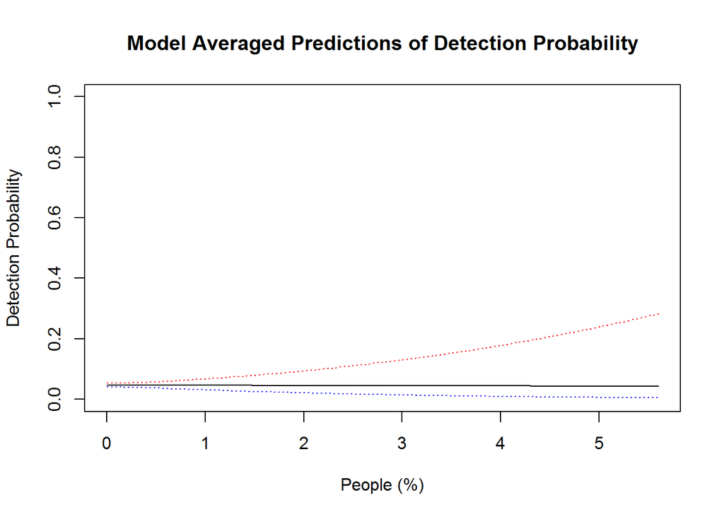

```r
plot(y=avg_nd$mod.avg.pred,x=seq(from=min, to=max,length.out=100),
     main='Model Averaged Predictions of Detection Probability',xlab='People (%)',
     ylab='Detection Probability',type='l',ylim=c(0,1))
lines(y=avg_nd$lower.CL,x=seq(from=min, to=max,length.out=100),lty=3,col='blue')
lines(y=avg_nd$upper.CL,x=seq(from=min, to=max,length.out=100),lty=3,col='red')
```

```r
## Now for occupancy

newdat1 <- data.frame(
Dist_5km = seq(from=min(site_covs$Dist_5km),
             to=max(site_covs$Dist_5km),length.out=100)
)

avgnd1 <- modavgPred(cand.set=cand.set,newdata=newdat1,
                     second.ord=F,parm.type='psi')
head(avgnd1)
```

```
## $type
## [1] "response"
##
## $mod.avg.pred
##   [1] 0.25993615 0.25400658 0.24816691 0.24241787 0.23676008 0.23119403
##   [7] 0.22572014 0.22033871 0.21504994 0.20985395 0.20475076 0.19974030
##  [13] 0.19482241 0.18999685 0.18526332 0.18062142 0.17607070 0.17161061
##  [19] 0.16724057 0.16295993 0.15876796 0.15466390 0.15064693 0.14671618
##  [25] 0.14287074 0.13910966 0.13543194 0.13183657 0.12832248 0.12488858
##  [31] 0.12153376 0.11825688 0.11505678 0.11193229 0.10888220 0.10590532
##  [37] 0.10300042 0.10016627 0.09740164 0.09470528 0.09207595 0.08951240
##  [43] 0.08701338 0.08457766 0.08220397 0.07989109 0.07763778 0.07544281
##  [49] 0.07330497 0.07122304 0.06919582 0.06722213 0.06530078 0.06343062
##  [55] 0.06161049 0.05983924 0.05811577 0.05643895 0.05480771 0.05322095
##  [61] 0.05167761 0.05017666 0.04871707 0.04729781 0.04591791 0.04457639
```

[output cut: 72 more lines]

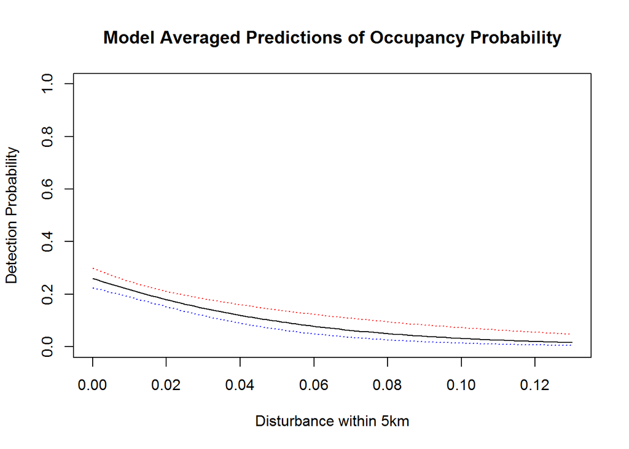

```r
plot(y=avgnd1$mod.avg.pred,x=seq(from=min(site_covs$Dist_5km),
                                 to=max(site_covs$Dist_5km),length.out=100),
     main='Model Averaged Predictions of Occupancy Probability',
     xlab='Disturbance within 5km',
     ylab='Detection Probability',type='l',ylim=c(0,1))
lines(y=avgnd1$lower.CL,x=seq(from=min(site_covs$Dist_5km), to=max(site_covs$Dist_5km),length.out=100),lty=3,col='blue')
lines(y=avgnd1$upper.CL,x=seq(from=min(site_covs$Dist_5km), to=max(site_covs$Dist_5km),length.out=100),lty=3,col='red')
```

5. Determine whether the top model is an adequate representation of the data-generating process. Use the sum of squared pearsons residuals (function below) as your test statistic. Report the test statistic obtained from fitted data, and generate 1000 realizations of the test statistic from simulated data (be patient, this may take a while). Obtain a p-value using your observed test statitic and the simulated distribution of test statistics. What null hypothesis are you evaluating? Do you reject or fail to reject this null hypothesis? What is the implication for evaluating goodness of fit?

```r
# Top model
summary(fit3)
```

```
##
## Call:
## occu(formula = ~1 ~ Dist_5km, data = occu_dat)
##
## Occupancy (logit-scale):
##             Estimate    SE      z  P(>|z|)
## (Intercept)    -1.05 0.101 -10.40 2.42e-25
## Dist_5km      -23.65 4.773  -4.96 7.23e-07
##
## Detection (logit-scale):
##  Estimate     SE     z P(>|z|)
##     -3.02 0.0732 -41.2       0
##
## AIC: 4461.006
## Number of sites: 1951
## optim convergence code: 0
## optim iterations: 52
## Bootstrap iterations: 0
```

```r
chisq <- function(mod){ # mod is fitted model
  obs <- getY(mod@data) # observed
  ex <- fitted(mod) # expected
  ts <- ((ex - obs) ^ 2) / (ex * (1 - ex))
return(sum(ts,na.rm=TRUE))
}

chisq(fit3)
```

```
## [1] 42730.33
```

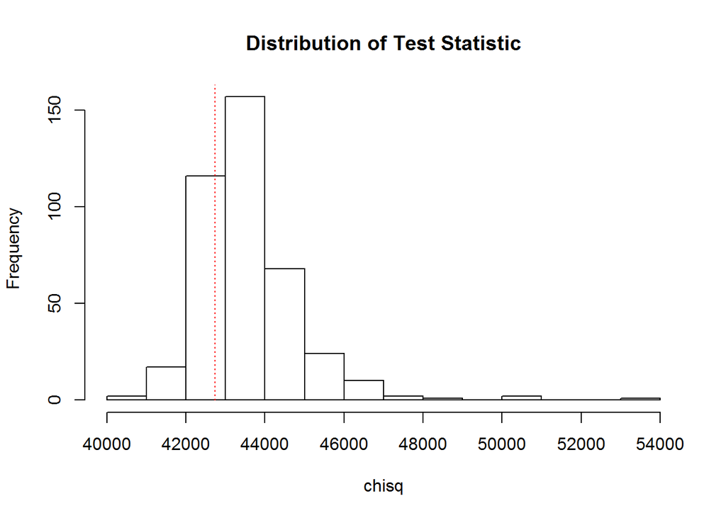

```r
library(unmarked)
sims <- parboot(object=fit3,statistic=chisq,nsim=400) # Couldn't do 1000 iterations
hist(sims@t.star[,1],xlab='chisq',
     main='Distribution of Test Statistic')
lines(x=rep(chisq(fit3),2),
      y=c(0,1000),
      col='red',lty=3)
```

```r
# Null hypothesis testing

sum(sims@t.star[,1] > chisq(fit3))/400
```

```
## [1] 0.7875
```

Le fin.